# Modèle linéaire multiple

2eme-FA-EMS - BUT SD - E. Anakok

## 0.1 Ce qu’il faut retenir de ce cours

**NoteModélisation probabiliste du modèle linéaire**

$y_i$ est la réalisation d’une variable aléatoire $Y_i$ telle que pour $1 \leq i \leq n$:

$$Y_i = \beta + \sum_{j=1}^p\alpha_j x_{i,j} + E_i, \quad E_i\overset{i.i.d.}\sim{\cal N}(0,\sigma^2)$$

**TipÉcriture matricielle du modèle**

Le modèle linéaire multiple peut s’écrire matriciellement

$$Y = X \theta + E$$

**TipEstimateur des moindres carrés de $\theta$**

$$\widehat{\theta} =\underset{\theta\in\mathbb{R}^{p+1}}{argmin} ||Y-X\theta||^2$$

Si $(X^t\,X)$ est inversible, alors

$$\textcolor{red}{\hat{\theta}=(X^t\,X)^{-1}\,X^t\,Y}$$

**TipVérification des hypothèses : Graphe de diagnostic, corrélation et vif**

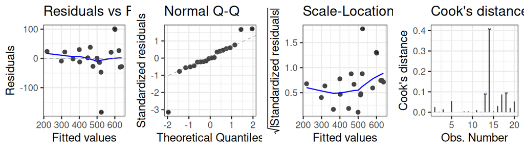

[figure not shown]

$$VIF(x_i) = \frac{1}{1-R^2(x_i)}$$

## 0.2 Problématique biologique

- **Données** On a pour 20 brèmes péchées dans le lac Laengelmavesi en Finland leurs poids (en gramme) et leurs longeurs (en cm), leurs largeurs (en cm) leurs épaisseur (en cm).

[figure not shown]

**WarningObjectif**

- Peut-on prédire le poids des poissons par leurs largeurs, leurs longueurs et leurs épaisseurs ?
- Tester le caractère significatif de la liaison : Y’a t’il un lien significatif entre le poids des poissons et leurs largeurs, leurs longueurs et leurs épaisseurs ?
- Y’a t’il un lien entre le poids du poisson et sa largeur après avoir pris en compte sa longueur et son épaisseur ?

# 1 Écriture et remarque sur le modèle

## 1.1 Écriture du modèle dans cet exemple

#### 1.1.0.1 Notations

On a $n = 20$ observations. On note, pour $1 \leq i \leq 20$

- $x_{1,i}$ la mesure de la longueur du poisson $i$.
- $x_{2,i}$ la mesure de la largeur du poisson $i$.
- $x_{3,i}$ la mesure de l’épaisseur du poisson $i$.
- $y_i$ la mesure du poids du poisson $i$.

**NoteDéfinition : Modèle de régression linéaire multiple**

On suppose que $y_i$ est la réalisation d’une variable aléatoire $Y_i$ telle que pour $1\leq i \leq n$

$$Y_i = \alpha_1 x_{1,i} + \alpha_2 x_{2,i} + \alpha_3 x_{3,i} + \beta + E_i$$

- $\alpha_1$ (resp $\alpha_2$ , $\alpha_3$ ) est un paramètre inconnu, l’effet de la longueur (resp largeur, épaisseur) sur le poids;
- $\beta$ est un paramètre inconnu;
- $E_i$ une variable aléatoire, $E_i \overset{i.i.d.}\sim \mathcal{N}(0, \sigma^2)$
- Les $x_i$ sont linéairement indépendants

## 1.2 Écriture plus générale du modèle

#### 1.2.0.1 Notations

On a $n = 20$ observations. On note, pour $1 \leq i \leq 20$

- $x_{1}, \dots, x_{p}$, $p$ variables explicatives et $y$ une variable réponse
- $y_i$ la mesure de la variable réponse de l’individu $i$.
- $\forall j \in \{ 1,\dots, p \}$, $x_{j,i}$ la valeur de la variable $x_j$ de l’individu $i$

**NoteDéfinition : Modèle de régression linéaire multiple**

On suppose que $y_i$ est la réalisation d’une variable aléatoire $Y_i$ telle que pour $1 \leq i \leq n$ :
$$Y_i = \sum_{j=1}^p \alpha_j x_{j,i} + \beta + E_i$$

- $\alpha_j$ est un paramètre inconnu, l’effet de la variable $x_j$ sur le y.
- $\beta$ est un paramètre inconnu.
- $E_i$ une variable aléatoire, $E_i \overset{i.i.d.}\sim \mathcal{N}(0, \sigma^2)$.
- Les $x_i$ sont linéairement indépendants.

## 1.3 Deux écritures équivalentes

**CautionRemarques**

Les deux modèles suivant sont équivalent :

- $\forall i \in \{1, \dots, n\} \;\;$

$$Y_i = \sum_{j=1}^p \alpha_j x_{j,i} + \beta + E_i,\quad \ E_i \overset{i.i.d.}\sim \mathcal{N}(0, \sigma^2)$$

- $\forall i \in \{1, \dots, n\} \;\;$

$$Y_i \overset{i.i.d.}\sim \mathcal{N}\left(\sum_{j=1}^p \alpha_j x_{j,i} + \beta, \sigma^2\right)$$

## 1.4 Dans l’exemple des poissons

**CautionRemarques**

Les deux modèles suivant sont équivalent :

- $\forall i \in \{1, \dots, n\} \;\;$
  $$Y_i = \alpha_1 x_{1,i} + \alpha_2 x_{2,i} + \alpha_3 x_{3,i} + \beta + E_i$$

$$E_i \overset{i.i.d.}\sim \mathcal{N}(0, \sigma^2)$$

- $\forall i \in \{1, \dots, n\} \;\;$
  $$Y_i \overset{i.i.d.}\sim \mathcal{N}\left(\alpha_1 x_{1,i} + \alpha_2 x_{2,i} + \alpha_3 x_{3,i} + \beta, \sigma^2\right)$$

## 1.5 Remarques sur les paramètres

**CautionRemarques**

Dans le modèle $\forall i \in \{1, \dots, n\} \;\;$

$$Y_i = \sum_{j=1}^p \alpha_j x_{j,i} + \beta + E_i,\quad\ E_i \overset{i.i.d.}\sim \mathcal{N}(0, \sigma^2)$$

- $\alpha_j$ représente l’accroissement de $Y_i$ correspondant à l’accroissement d’une unité sur $x_j$ si les autres variables explicatives sont fixées. Dans l’exemple des poissons : $\alpha_1$ represente l’accroissement du poids correspondant à l’accroissement d’1 cm sur la longeurs du poisson si la largeur et l’épaisseur son fixé.
- Ce modèle est de dimension $p + 1$. (Avec $p+1$ paramètres d’espérance à estimer $p$ pour $\alpha$ et $1$ pour$\beta$)
- $\forall i \in \{1, \dots, n\}$ $Y_i$ se décompose en $\color{red}{Y_i} = {\color{blue}{\underbrace{\displaystyle\sum_{j=1}^p \alpha_j x_{j,i} + \beta}_{{déterministe}{}}}} + \color{red}{\overbrace{E_i}^{aléatoire}}$

# 2 Écriture matricielle du modèle

## 2.1 Rappel sur les matrices

1. Qu’est ce qu’une matrice ?
2. La multiplication matricielle
3. La transposée d’une matrice
4. L’inverse d’une matrice
5. Petits topo sur les vecteurs

## 2.2 Rappels d’algèbre

**NoteRappel : Matrice**

$A = (a_{i,j})_{1\leq i \leq p, 1\leq j \leq q}$ est une **matrice** à coefficients réels de format $(p \times q)$

$$A = \begin{bmatrix}
a_{11} & a_{12} & \ldots & a_{1q}\\
a_{21} & a_{22} & \ldots & a_{2q}\\
\vdots & \vdots & & \vdots \\
a_{p1} & a_{p2} & \ldots & a_{pq}
\end{bmatrix}$$

**NoteRappel : Transposée d’une matrice**

Si $A = (a_{i,j})_{1\leq i \leq p, 1\leq j \leq q}$ est une matrice $(p \times q)$, on note alors $A^t$ sa **transposée**, la matrice $(q \times p)$ définie par

$$A^t = \begin{bmatrix}
a_{11} & a_{21} & \ldots & a_{p1}\\
a_{12} & a_{22} & \ldots & a_{p2}\\
\vdots & \vdots & & \vdots \\
a_{1q} & a_{2q} & \ldots & a_{pq}
\end{bmatrix}$$

**NoteRappel : Matrice symétrique**

$A$ est une **matrice symétrique** si :

- $A$ est une matrice carré ($p=q$)
- $A^t = A$

**NoteRappel : Transposée du produit**

Soit $A$ et $B$ deux matrices. On a

$$(A B)^t = B^t A^t$$

## 2.3 Rappels d’algèbre : Vecteur

**NoteRappel : Vecteurs**

- On note V un **vecteur** à $p$ éléments par

$$V = \begin{bmatrix} v_{1} \\ v_{2}\\ \vdots \\ v_{p} \end{bmatrix}= \left[{v_1, v_2, \ldots, v_p}\right]^t$$

## 2.4 Rappels d’algèbre : Vecteur

**NoteRappel : Produit matrice-vecteur**

Si $V$ est un vecteur à $q$ éléments et $A$ une matrice $(p \times q)$ alors, $U=AV$ est un vecteur à $p$ éléments

$$\begin{align} U &= \begin{bmatrix} u_{1} \\ u_{2}\\ \vdots \\ u_{p} \end{bmatrix} = AV \\ \\
AV&=\begin{bmatrix}
a_{11} & a_{12} & \ldots & a_{1q}\\
a_{21} & a_{22} & \ldots & a_{2q}\\
\vdots & \vdots & & \vdots \\
a_{p1} & a_{p2} & \ldots & a_{pq}
\end{bmatrix}\begin{bmatrix} v_{1} \\ v_{2}\\ \vdots \\ v_{p} \end{bmatrix}\\ \\AV&= \begin{bmatrix} \sum_{j=1}^{q} a_{1j} v_j \\ \sum_{j=1}^{q} a_{2j} v_j\\ \vdots \\
\sum_{j=1}^{q} a_{pj} \end{bmatrix} \end{align}$$

## 2.5 Rappels d’algèbre : Identité et inverse

**NoteRappel : matrice identité**

La matrice **identité** $I_n$ est la matrice carré à $n$ lignes et $n$ colonnes, dont les coefficients diagonaux valent $1$ et les autres valent $0$.

$$I_n = \begin{bmatrix}
1 & 0 & \ldots & 0\\
0 & 1 & \ldots & 0\\
\vdots & \vdots & & \vdots \\
0 & 0 & \ldots & 1
\end{bmatrix}$$

**NoteRappel : Inverse d’une matrice**

Si $A = (a_{i,j})_{1\leq i \leq p, 1\leq j \leq p}$ est une matrice carrée $(p \times p)$ **inversible**, alors on note son **inverse** $A^{-1}$ la matrice $(p \times p)$ telle que

$$A\,A^{-1} = A^{-1}\,A = I_p$$

**NoteRappel : Transposée de l’inverse**

Si $A$ est une matrice inversible, alors

$$(A^{-1})^t=(A^t)^{-1}$$

## 2.6 Vecteurs aléatoires

**NoteRappel : Vecteurs aléatoires**

Soient $V_1,V_2,\dots,V_n$, $n$ variables aléatoires réelles, alors

$$V = \begin{bmatrix} V_1 \\ V_2 \\ \vdots \\ V_n \end{bmatrix}$$

**NoteRappel : Espérance d’un vecteur aléatoire**

$V$ a pour **espérance**

$$\mathbb{E}[V] = \begin{bmatrix} \mathbb{E}[V_1] \\ \mathbb{E}[V_2] \\ \vdots \\ \mathbb{E}[V_n] \end{bmatrix}$$

**NoteRappel : Matrice de variance-covariance**

$V$ a pour matrice de **variance-covariance** (symétrique)

$$\mathbb{V}[V] = \mathbb{E}\left[\left(V- \mathbb{E}[V] \right)\left(V- \mathbb{E}[V] \right)^t \right] =$$

$$\begin{bmatrix} \mathbb{V}[V_1] & cov(V_1,V_2) & \dots& Cov(V_1,V_n) \\
cov(V_2,V_1) & \mathbb{V}[V_2] & \dots& Cov(V_2,V_n) \\
\vdots & \vdots & \ddots & \vdots \\
cov(V_n,V_1) & cov(V_n,V_2) & \dots& \mathbb{V}[V_n]\end{bmatrix}$$

## 2.7 Propriétés

**TipThéorème**

Soient $\textcolor{blue}{A}$ et $\textcolor{blue}{B}$ des matrices à coefficients non aléatoires et soit $\textcolor{red}{V}$ un vecteur aléatoire, alors

$$\begin{align}
\mathbb{E}[\textcolor{blue}{A}\textcolor{red}{V}\textcolor{blue}{B}] &= \textcolor{blue}{A} \mathbb{E}[\textcolor{red}{V}]\textcolor{blue}{B}\\
\mathbb{V}[\textcolor{blue}{A}\textcolor{red}{V}] & = \textcolor{blue}{A} \mathbb{V}[\textcolor{red}{V}] \textcolor{blue}{A^t}
\end{align}$$

**NoteRappel : Vecteurs gaussiens**

Si $V_1, V_2, \ldots, V_n$ sont gaussiennes et indépendantes, alors $V = [V_1, \ldots, V_n]^t$ est **un vecteur gaussien**.

Si $V_1, V_2, \ldots, V_n \overset{i.i.d}\sim \mathcal{N}(0,\sigma ^2)$, alors

$$V \sim \mathcal{N}\left(\vec{0}_n,\,\sigma^2 I_n\right)$$
où $I_n$ est la matrice identité d’ordre $n$.

## 2.8 Écriture matricielle du modèle

**TipThéorème**

$$\left\{\begin{matrix}
Y_1 = \beta\ +\ \alpha_1\,x_{1,1}\ +\ \alpha_2\,x_{2,1}\ +\
\ldots\ +\ \alpha_{p}\,x_{p, 1}\ +\ E_1\\
Y_2 = \beta\ +\ \alpha_1\,x_{1, 2}\ +\ \alpha_2\,x_{2,2}\ +\
\ldots\ +\ \alpha_{p}\,x_{p, 2}\ +\ E_2\\
\vdots \\
Y_n = \beta\ +\ \alpha_1\,x_{1,n}\ +\ \alpha_2\,x_{2, n}\ +\
\ldots\ +\ \alpha_{p}\,x_{p,n}\ +\ E_n \end{matrix} \right.$$

peut se réécrire sous la forme

$$Y = X \theta + E$$

avec

$$Y =\begin{bmatrix} Y_1\\ Y_2\\ \vdots \\ Y_n\end{bmatrix},\quad X = \begin{bmatrix}
1 & x_{1,1} & \ldots & x_{p, 1}\\
1 & x_{1, 2} & \ldots & x_{p, 2}\\
\vdots & \vdots & & \vdots \\
1 & x_{1, n} & \ldots & x_{p, n}
\end{bmatrix}$$

$$\theta = \begin{bmatrix} \beta\\ \alpha_1\\
\alpha_2\\ \vdots \\ \alpha_{p}\end{bmatrix},\quad E = \begin{bmatrix}E_1\\
E_2\\ \vdots \\ E_n\end{bmatrix}$$

## 2.9 Écriture matricielle du modèle

**TipPropriété**

- $X$ est de taille $n\times (p+1)$
- $\theta$ est de dimension $(p+1)\times 1$ : vecteur des paramètres d’espérance
- $E$ est de dimension $(n\times 1)$ : est un vecteur Gaussien tel que

$$E \sim \mathcal{N}\left(\vec{0}_n,\,\sigma^2 I_n\right)$$

- $Y$ est de dimension $(n\times 1)$ : est un vecteur Gaussien tel que

$$Y \sim \mathcal{N}\left(X\theta,\,\sigma^2 I_n\right)$$

**CautionRemarques**

Si les vecteurs colonnes de $X$ sont linéairement indépendants, $X$ est de rang $p+1$ et $X^t X$ est inversible.

## 2.10 Exercice : écrire le modèle linéaire univarié sous forme matricielle

Le modèle de régression simple
$$Y_i=\alpha x_i+\beta+E_i$$
s’écrit matriciellement $Y=X\theta+E$ avec
$$Y = \begin{bmatrix} Y_1\\ Y_2\\ \vdots \\ Y_n\end{bmatrix},\quad
X = \begin{bmatrix}
1 & x_{1} \\
1 & x_{2} \\
\vdots & \\
1 & x_{n} \\
\end{bmatrix}$$

$$\theta\ =\ \begin{bmatrix}\beta\\ \alpha\end{bmatrix},\quad
E\ =\ \begin{bmatrix} E_1\\
E_2\\ \vdots \\ E_n\end{bmatrix}$$

## 2.11 Écriture du modèle linéaire simple

**TipPropriété**

- $X$ est de taille $(n\times 2)$
- $\theta$ est de dimension $(2 \times 1)$ : vecteur des paramètres d’espérance
- $E$ est de dimension $(n\times 1)$ : est un vecteur Gaussien tel que

$$E \sim \mathcal{N}\left(\vec{0}_n,\,\sigma^2 I_n\right)$$

- $Y$ est de dimension $(n\times 1)$ : est un vecteur Gaussien tel que

$$Y \sim \mathcal{N}\left(X\theta,\,\sigma^2 I_n\right)$$

**CautionRemarques**

Si les $x_i$ ne sont pas tous égaux, les deux vecteurs colonnes de $X$ sont linéairement indépendants et $X$ est de rang $p = 2$.

## 2.12 Exemple sur les poissons

#### 2.12.0.1 Notations

On a $n = 20$ observations. On note, pour $1 \leq i \leq 20$

- $x_{1,i}$ la mesure de la longueur du poisson $i$.
- $x_{2,i}$ la mesure de la largeur du poisson $i$.
- $x_{3,i}$ la mesure de l’épaisseur du poisson $i$.
- $y_i$ la mesure du poids du poisson $i$.

**NoteDéfinition : Modèle de régression linéaire multiple**

On suppose que $y_i$ est la réalisation d’une variable aléatoire $Y_i$ telle que pour $1 \leq i \leq n$ :

$$Y_i = \alpha_1 x_{1,i} + \alpha_2 x_{2,i} + \alpha_3 x_{3,i} + \beta + E_i,\quad$$

- $\alpha_1$ (resp $\alpha_2$ , $\alpha_3$ ) est un paramètre inconnu, l’effet de la longueur (resp largeur, épaisseur) sur le poids;
- $\beta$ est un paramètre inconnu;
- $E_i$ une variable aléatoire, $E_i \overset{i.i.d.}\sim \mathcal{N}(0, \sigma^2)$
- Les $x_i$ sont linéairement indépendants

## 2.13 Comment écrire le modèle :

$$\left\{\begin{matrix}
Y_1 = \beta\ +\ \alpha_1\,x_{1,1}\ +\ \alpha_2\,x_{2,1}\
+\ \alpha_{3}\,x_{3, 1}\ +\ E_1\\
Y_2 = \beta\ +\ \alpha_1\,x_{1, 2}\ +\ \alpha_2\,x_{2,2}\ +\
\alpha_{3}\,x_{3, 2}\ +\ E_2\\
\vdots \\
Y_n = \beta\ +\ \alpha_1\,x_{1,n}\ +\ \alpha_2\,x_{2, n}\ +\
\alpha_{3}\,x_{3,n}\ +\ E_n \end{matrix} \right.$$

peut se réécrire sous la forme

$$Y = X \theta + E$$

avec

$$Y =\begin{bmatrix} Y_1\\ Y_2\\ \vdots \\ Y_n\end{bmatrix},\quad X = \begin{bmatrix}
1 & x_{1,1} & x_{2,1} & x_{3, 1}\\
1 & x_{1, 2} & x_{2,1} & x_{3, 2}\\
\vdots & \vdots & & \vdots \\
1 & x_{1, n} & x_{2,1} & x_{3, n}
\end{bmatrix}$$

$$\theta = \begin{bmatrix} \beta\\ \alpha_1\\
\alpha_2\\\vdots\\ \alpha_{3}\end{bmatrix},\quad E = \begin{bmatrix}E_1\\
E_2\\ \vdots \\ E_n\end{bmatrix}$$

## 2.14 Avec les données :

$$X =$$

| Intercept | Length1 | Height | Width |
| --- | --- | --- | --- |
| 1 | 23.2 | 11.5200 | 4.0200 |
| 1 | 24.0 | 12.4800 | 4.3056 |
| 1 | 23.9 | 12.3778 | 4.6961 |
| 1 | 26.3 | 12.7300 | 4.4555 |
| 1 | 26.5 | 12.4440 | 5.1340 |
| 1 | 26.8 | 13.6024 | 4.9274 |
| 1 | 26.8 | 14.1795 | 5.2785 |
| 1 | 27.6 | 12.6700 | 4.6900 |
| 1 | 27.6 | 14.0049 | 4.8438 |
| 1 | 28.5 | 14.2266 | 4.9594 |

# 3 Estimation des paramètres d’espérance du modèle

## 3.1 Estimateurs des moindres carrés

**WarningObjectif**

On note $\theta= [\beta,\alpha_1,...,\alpha_p]^t$.

Comme dans la regression linéaire simple on cherche à minimiser :

$$J(\theta) = \sum_{i = 1}^n \left( y_i -(\beta + \sum_{j=1}^p \alpha _j x_{j,i}) \right)^2$$
Écriture matricielle ?

## 3.2 Rappels d’algèbre : norme

**NoteRappel : norme**

Soit
$$V\ =\ \begin{bmatrix} v_{1} \\ v_{2}\\ \vdots \\ v_{n}\end{bmatrix}
\ =\ [v_1, \ldots, v_n]^t$$
un vecteur de $\mathbb{R}^n$. On appelle norme de $V$ le réel

$$\displaystyle V^t V \ =\ \sum_{i=1}^{n} v_i^2\ =\ ||V||^2$$

**CautionRemarque**

$$V^t V \neq V V^t$$

$$V V^t = \begin{bmatrix} v_1^2 & v_1\,v_2 & \ldots & v_1\,v_n\\
v_2\,v_1 & v_2^2 & \ldots & v_2\,v_n\\
\vdots & \vdots & & \vdots \\
v_n\,v_1 & v_n\,v_2 & \ldots & v_n^2 \end{bmatrix}$$

## 3.3 Estimateurs des moindres carrés

**WarningObjectif**

On souhaite trouver $\theta= (\beta,\alpha_1,...\alpha_p)^t$ qui minimise

$$\begin{align}J(\theta)&=\sum_{i = 1}^n \left( y_i -(\beta + \sum_{j=1}^p \alpha _j x_{j,i}) \right)^2 \\&= (Y-X\theta)^t(Y-X\theta) \\&= ||Y-X\theta||^2\end{align}$$

**TipThéorème**

Le $\theta$ optimal est la solution du système de $p+1$ équations à $p+1$ inconnues

$$\left\{\begin{array}{ccc}
\frac{\partial \sum_{i = 1}^n \left( y_i -(\beta + \sum_{j=1}^p \alpha _j x_{j,i}) \right)^2 }{\partial \beta} & = & 0 \\
%
\frac{\partial \sum_{i = 1}^n \left( y_i -(\beta + \sum_{j=1}^p \alpha _j x_{j,i}) \right)^2 }{\partial \alpha_1} & = & 0\\
\vdots & & \\
\frac{\partial \sum_{i = 1}^n \left( y_i -(\beta + \sum_{j=1}^p \alpha _j x_{j,i}) \right)^2 }{\partial \alpha_p} & = & 0
\end{array}\right.$$

## 3.4 À la recherche de $\widehat{\theta}$

**NoteEstimateur des moindres carrés**

$$\begin{align}\widehat{\theta} &= \underset{\theta\in\mathbb{R}^{p+1}}{argmin} (Y-X\theta)^t(Y-X\theta) \\ \widehat{\theta}&=\underset{\theta\in\mathbb{R}^{p+1}}{argmin} ||Y-X\theta||^2\end{align}$$

$\widehat{\theta} = [B,A_1, \dots, A_p]^t$ où $B$ est l’estimateur de $\beta$ et $A_j$ l’estimateur de $\alpha_j$

**TipÉcriture matricielle des équations**

$$\begin{align}
J(\theta) &= (Y-X\theta)^t(Y-X\theta)\\
&=(Y^t-\theta^tX^t)(Y-X\theta)\\
&= Y^tY - Y^tX\theta -\theta^tX^t Y +\theta^tX^tX\theta \\
&= Y^tY - 2 Y^tX\theta +\theta^tX^tX\theta
\end{align}$$

En dérivant par rapport à $\theta$ on obtient :
$$-2Y^tX + 2\theta^tX^tX$$

Le système $-2Y^tX + 2\theta^tX^tX=0$ est bien le même que les $p+1$ équations de la slide précédente

## 3.5 À la recherche de $\widehat{\theta}$

**CautionRemarques**

$X$ est de rang $p+1$ donc $X^tX$ est inversible.

**TipFin du calcul**

$$\begin{align}
-2Y^tX + 2\widehat{\theta}^tX^tX = 0 &\iff \widehat{\theta}^tX^tX = Y^tX \\
\iff X^tX \widehat{\theta} = X^tY & \iff \widehat{\theta} = (X^tX)^{-1} X^tY
\end{align}$$

**TipThéorème**

$$\widehat{\theta} =\underset{\theta\in\mathbb{R}^{p+1}}{argmin} ||Y-X\theta||^2$$
a pour solution

$$\widehat{\theta} = (X^tX)^{-1} X^tY$$

## 3.6 Estimateurs des paramètres d’espérance

**WarningObjectif : Estimateur des moindres carrés de $\theta$**

$$\widehat{\theta} =\underset{\theta\in\mathbb{R}^{p+1}}{argmin} ||Y-X\theta||^2$$

**TipThéorème**

- Si $\hat{\theta}= [B, A_1, \ldots, A_{p}]^t$ est solution du système et que $(X^t\,X)$ est inversible, alors

$$\hat{\theta}=(X^t\,X)^{-1}\,X^t\,Y$$

| Paramètres | Estimateurs | Estimations |
| --- | --- | --- |
| $[\beta,\alpha_1,...\alpha_p]$ | $[B, A_1, \ldots, A_{p}]$ | $[b,a_1,\cdots,a_p]$ |

# 4 Validation des hypothèses et estimation avec R

## 4.1 Les 4 graphiques

[figure not shown]

## 4.2 Multicolinéarité des $x_i$

On vérifie la corrélation entre les $x_i$

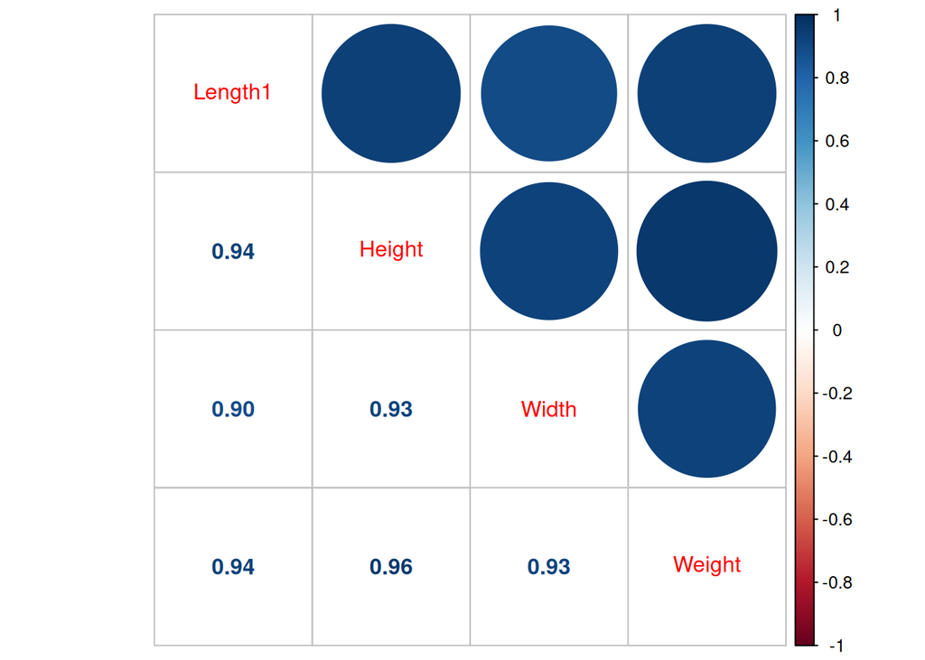

```r
library(corrplot)
M = cor(fish[c("Length1","Height","Width","Weight")])
corrplot.mixed(M)
```

## 4.3 Vérification avec le VIF

**NoteDéfinition : VIF**

$$VIF(x_i) = \frac{1}{1-R^2(x_i)}$$
où $R^2(x_i)$ est le $R^2$ du modèle linéaire dans lequel on explique $x_i$ par toutes les autres covariables ($x_j$)

## 4.4 Exemple du VIF sur les poissons :

Calcul ‘à la main’

```r
mod_length<- lm(Length1 ~ Height + Width , data =  fish)
vif_length <- 1/ ( 1-summary(mod_length)$r.squared)
print(vif_length)
```

```
[1] 8.952978
```

Avec la fonction VIF :

```r
library(car)
vif(mod)
```

```
  Length1    Height     Width
 8.952978 12.123683  7.451746
```

**En pratique :** on retire les covariables qui ont un VIF supérieur à 10 (ou 5 si on veut être plus strict)

## 4.5 Estimations des paramètres sur notre exemple :

```r
mod <- lm(Weight ~Length1 + Height + Width , data =  fish)
summary(mod)
```

```
Call:
lm(formula = Weight ~ Length1 + Height + Width, data = fish)

Residuals:
     Min       1Q   Median       3Q      Max
-183.872  -17.044   -0.495   24.591  101.032

Coefficients:
            Estimate Std. Error t value Pr(>|t|)
(Intercept) -1048.57     187.86  -5.582 4.13e-05 ***
Length1        18.96      13.26   1.430    0.172
Height         48.50      28.31   1.713    0.106
Width          66.72      51.73   1.290    0.215
---
Signif. codes:  0 '***' 0.001 '**' 0.01 '*' 0.05 '.' 0.1 ' ' 1

Residual standard error: 63.03 on 16 degrees of freedom
Multiple R-squared:  0.808, Adjusted R-squared:  0.772
F-statistic: 22.44 on 3 and 16 DF,  p-value: 5.624e-06
```

## 4.6 Sur notre exemple (sans la fonction lm)

1. On récupère les matrices $X$ et $Y$ :

```r
X1 <- fish[, c("Length1",  "Height",  "Width")] %>%
  as.matrix()
X <- cbind(Intercept = 1,X1)
Y <- fish[,"Weight"] %>%
  as.matrix()
```

## 4.7 Sur notre exemple (sans la fonction lm)

2. On cherche maintenant $\widehat{\theta}=(X^t\,X)^{-1}\,X^t\,Y$.

Le produit matriciel $AB$ s’obtient en faisant `A %*% B`, La transposée d’une matrice A s’obtient avec la fonction `t(A)` et son inverse avec la fonction `solve(A)`.

- $X^t\,X$ s’obtient donc :

```r
t(X) %*% X
```

- $(X^t\,X)^{-1}$ s’obtient donc :

```r
solve(t(X) %*% X)
```

On a finalement $\widehat{\theta}$ :

```r
solve(t(X) %*% X)%*% t(X)%*% Y
```

## 4.8 On retrouve bien les mêmes valeurs

```r
coefficients(mod)
```

```
(Intercept)     Length1      Height       Width
-1048.57013    18.95867    48.49646    66.71559
```

```r
solve(t(X) %*% X)%*% t(X)%*% Y
```

```
                 [,1]
Intercept -1048.57013
Length1      18.95867
Height       48.49646
Width        66.71559
```

## 4.9 Ce qu’il faut retenir de ce cours

**NoteModélisation probabiliste du modèle linéaire**

$y_i$ est la réalisation d’une variable aléatoire $Y_i$ telle que pour $1 \leq i \leq n$:

$$Y_i = \beta + \sum_{j=1}^p\alpha_j x_{i,j} + E_i, \quad E_i\overset{i.i.d.}\sim{\cal N}(0,\sigma^2)$$

**TipÉcriture matricielle du modèle**

Le modèle linéaire multiple peut s’écrire matriciellement

$$\textcolor{red}{Y = X \theta + E}$$

**TipEstimateur des moindres carrés de $\theta$**

$$\widehat{\theta} =\underset{\theta\in\mathbb{R}^{p+1}}{argmin} ||Y-X\theta||^2$$

Si $(X^t\,X)$ est inversible, alors $\hat{\theta}=(X^t\,X)^{-1}\,X^t\,Y$

**TipVérification des hypothèses : Graphe de diagnostic, corrélation et vif**

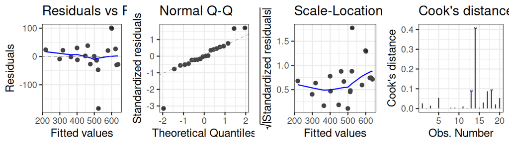

[figure not shown]

$$VIF(x_i) = \frac{1}{1-R^2(x_i)}$$

# 5 Estimateur de la variance

## 5.1 Ce qu’il faut retenir de ce cours 1/2

**NoteEstimateur de $\sigma^2$ et loi**

$${S^2}_{(M_{p+1})}=\frac{SCR(M_{p+1})}{n-(p+1)}=\frac{||Y - X\,\widehat{\theta}||^2}{n-p-1}$$

$$\frac{(n-p-1){S^2}_{(M_{p+1})}}{\sigma^2}\sim\chi^2(n-p-1)$$

**TipLoi de $\widehat{\theta}$ et $\widehat{\theta}_k$**

$$\widehat{\theta} \sim \mathcal{N}\left(\theta,\sigma^2(X^tX)^{-1}\right)$$
$$\widehat{\theta}_k \sim \mathcal{N}\left(\theta_k,\sigma^2c_{kk}\right)\text{ avec } c_{kk} = (X^tX)^{-1}_{k,k}$$

$$\frac{\widehat{\theta}_k- \theta_k}{\sqrt{S^2_{(M_{p+1})}c_{kk}}}\sim\mathcal{T}(n-p-1)$$

**TipIntervalle de confiance de $\theta_k$**

$$\begin{align} IC_{1-\delta}(\theta_k) =
&\left[\hat{\theta}_k-t_{1-\frac{\delta}{2}} \sqrt{{S^2}_{(M_{p+1})}c_{kk}}\right.;\\ &\;\left.\hat{\theta}_k+t_{1-\frac{\delta}{2}} \sqrt{{S^2}_{(M_{p+1})}c_{kk}}\;\right]\end{align}$$

## 5.2 Ce qu’il faut retenir de ce cours 2/2

**NoteTest de Student de la nullité de la pente**

$$H_0:\alpha_k=0$$

$$H_1:\alpha_k\neq 0$$

**NoteTest de Fisher de comparaison de $M_1$ contre $M_{p+1}$**

$$H_0\; :\; \text{modèle}\; M_1:$$
$$Y_i=\beta+E_i,\quad E_i\; \overset{i.i.d.}{\sim} {\cal N}(0,\sigma^2)$$

$$H_1\; :\; \text{modèle}\; M_{p+1}:$$
$$Y_i= \beta + \sum_{j=1}^p\alpha_j x_{j,i}+E_i,\; E_i\; \overset{i.i.d.}{\sim}
{\cal N}(0,\sigma^2)$$

**TipTest de Fisher de comparaison de $M_{q+1}$ contre $M_{p+1}$**

Pour $q<p$, on veut tester

$$H_0\; :\; \text{modèle}\; M_{q+1}:$$

$$Y_i=\beta+ \sum_{j=1}^q\alpha_j x_{j,i}+E_i,\quad E_i\; \overset{i.i.d.}{\sim} {\cal N}(0,\sigma^2)$$

$$H_1\; :\; \text{modèle}\; M_{p+1}:$$

$$Y_i= \beta + \sum_{j=1}^p\alpha_j x_{j,i}+E_i,\quad E_i\; \overset{i.i.d.}{\sim}
{\cal N}(0,\sigma^2)$$

$$\begin{align}T_n &= \frac{\left(SCR(M_{q+1}) - SCR(M_{p+1})\right)\Bigl/(p-q)}{SCR(M_{p+1})\Bigl/~(n-p-1)}\\& \sim_{H_0}^{}~\mathcal{F}(p-q\,,\,n-p-1)\end{align}$$

## 5.3 Dans le modèle linéaire simple

**NoteRappel**

Dans le modèle $M_2$ : $\forall i \in \{1, \dots, n\} \;\;$
$$Y_i =\beta + \alpha x_i + E_i,\quad E_i \overset{i.i.d.}{\sim}\mathcal{N}(0, \sigma^2)$$

L’estimateur de la variance résiduelle était :

$$\begin{align}
S^2 &= \frac{1}{n-2}\sum_{i=1}^n(Y_i-\widehat{Y_i})^2\\
&=\frac{1}{n-2}\sum_{i=1}^n(Y_i-Ax_i-B)^2\\
&= \frac{SCR(M_2)}{n-2},
\end{align}$$

où $\widehat{Y_i}=Ax_i+B$, la prévision (aléatoire) par le modèle de régression linéaire associée à $x_i$.

## 5.4 Le paramètre de variance résiduelle

**WarningObjectif**

Dans le modèle $M_{p+1}$:

$\forall i \in \{1, \dots, n\} \;\;$
$$Y_i =\beta + \sum_{j=1}^p\alpha_j x_{j,i} + E_i, \quad E_i \overset{i.i.d.}{\sim}\mathcal{N}(0, \sigma^2)$$

il y’a un paramètre de variance $\sigma ^2$ : la variance residuelle.

Quel est son estimateur ?

## 5.5 Estimation de la variance residuelle du modèle

**NoteDéfinition : Prévision aléatoire par le modèle $M_{p+1}$**

$$\begin{align}\widehat{Y_i}&=B+A_1x_{i,1}+\cdots+A_px_{i,p}\\&=B+\sum_{j=1}^p A_jx_{i,j}\end{align}$$

**NoteDéfinition : Résidus aléatoires du modèle $M_{p+1}$**

$$E_i=Y_i-\widehat{Y_i}$$

**NoteDéfinition : Somme des carrés résiduels**

$$\begin{align}SCR(M_{p+1})&=\sum_{i=1}^n E_i^2 \\ &=\sum_{i=1}^n\left(Y_i-(B+\sum_{j=1}^p A_jx_{i,j})\right)^2\end{align}$$

## 5.6 D’un point de vue matriciel

**NoteDéfinition : Vecteur (aléatoire) des prévisions**

$$\widehat{Y}\ =\ \begin{bmatrix} \widehat{Y_1}\\
\widehat{Y_2}\\ \vdots \\ \widehat{Y_n}\end{bmatrix}=\ \begin{bmatrix} B+\sum_{j=1}^p A_jx_{1,j}\\
B+\sum_{j=1}^p A_jx_{2,j}\\ \vdots \\ B+\sum_{j=1}^p A_jx_{n,j}\end{bmatrix}=X\hat{\theta}$$

**NoteDéfinition : Vecteur (aléatoire) des résidus**

$$E\ =\ \begin{bmatrix} E_1\\
E_2\\ \vdots \\ E_n\end{bmatrix}=\ \begin{bmatrix} Y_1-\widehat{Y_1}\\
Y_2-\widehat{Y_2}\\ \vdots \\ Y_n-\widehat{Y_n}\end{bmatrix}=Y-X\hat{\theta}$$

**NoteDéfinition : Somme des carrés résiduels**

$$\begin{align}SCR(M_{p+1})&=\sum_{i=1}^n E_i^2 \\
&= ||E||^2\\
&=||Y-X\hat{\theta}||^2\end{align}$$

## 5.7 Estimateur de la variance résiduelle $\sigma^2$

**NoteDéfinition : Estimateur de $\sigma^2$**

$$\begin{align}
{S^2}_{(M_{p+1})}&=\frac{SCR(M_{p+1})}{n-(p+1)}\\
&=\frac{1}{n-p-1}\sum_{i=1}^n E_i^2\end{align}$$

$$\begin{align}{S^2}_{(M_{p+1})}&=\frac{\displaystyle\sum_{i=1}^n\left(Y_i-(B+\sum_{j=1}^p A_jx_{i,j})\right)^2}{n-p-1}\\
&=\frac{||Y - X\,\hat{\theta}||^2}{n-p-1}
\end{align}$$

**NoteDéfinition : Estimation de $\sigma^2$**

Réalisation $s^2$ de ${S^2}_{(M_{p+1})}$ sur les données

$$\begin{align}s^2&=\frac{1}{n-p-1}\sum_{i=1}^n e_i(M_{p+1})^2\\&=\sum_{i=1}^n(y_i-(b+a_1x_{i,1}+\cdots+a_px_{i,p}))^2\end{align}$$
où $e_i(M_{p+1})$ sont les résidus observés dans le modèle $M_{p+1}$

# 6 Propriétés et lois des estimateurs

## 6.1 Propriétés et lois de $S^2$

**TipThéorème**

Sous les hypothèses du modèle linéaire gaussien, ${S^2}_{(M_{p+1})}$ est un estimateur sans biais de $\sigma^2$ et on a
$$\begin{align}&\frac{(n-p-1){S^2}_{(M_{p+1})}}{\sigma^2}\\
&=\frac{\sum_{i=1}^n(Y_i-B-\sum_{j=1}^pA_jx_{i,j})^2}{\sigma^2}\\&\sim\chi^2(n-p-1)\end{align}$$

De plus ${S^2}_{(M_{p+1})}$ est indépendant de $\hat{\theta}$.

## 6.2 Propriétés et loi de $\hat{\theta}$

**TipThéorème**

$\hat{\theta}$ est un vecteur gaussien d’espérance $\theta$ et de matrice de variance-covariance

$$Var(\hat{\theta})=\sigma^2(X^t\,X)^{-1}$$

estimée par

$$S^2(\hat{\theta})={S^2}_{(M_{p+1})}(X^t\,X)^{-1}$$

On montre que
$$\widehat{\theta}\sim{\cal N}(\theta\,,\,\sigma^2(X^t\,X)^{-1})$$

En particulier, pour tout $k=1,\cdots,p+1$, si $c_{kk}={(X^t\,X)^{-1}}_{kk}$ désigne le $k$-ème élément diagonal de $(X^t\,X)^{-1}$, et $\widehat{\theta}_k$ désigne le $k$-ème élément du vecteur $\hat{\theta}$, on a
$$\widehat{\theta}_k\sim{\cal N}(\theta_k\,,\,\sigma^2c_{kk})$$

En remplaçant $\sigma^2$ par son estimateur on a,
$$\frac{(\widehat{\theta}_k-\theta_k)}{\sqrt{{S^2}_{(M_{p+1})}c_{kk}}}\sim \mathcal{T}{(n-p-1)}$$

## 6.3 Démonstrations

On rappelle que
$$\hat{\theta}=(X^t\,X)^{-1} X^t Y$$

$$\begin{align}E(\hat{\theta})&=E((X^t\,X)^{-1} X^t Y)\\
&=(X^t\,X)^{-1} X^t E(Y)\\
&=(X^t\,X)^{-1} X^t X\theta\\
&=\theta
\end{align}$$

$$\begin{align}
{\rm{Var}}(\hat{\theta})&={\rm{Var}}((X^t\,X)^{-1} X^t Y)\\
&= (X^t\,X)^{-1} X^t {\rm{Var}}(Y) (X^t\,X)^{-1} X^t)^t\\
&= (X^t\,X)^{-1} X^t \sigma^2I_n ((X^t\,X)^{-1} X^t)^t\\
&= \sigma^2(X^t\,X)^{-1} X^t (X^t\,X)^{-1} X^t)^t\\
&= \sigma^2(X^t\,X)^{-1} X^t ((X^t)^t) ((X^t\,X)^{-1})^t \\
&= \sigma^2(X^t\,X)^{-1} X^t X ((X^t\,X)^{t})^{-1} \\
&= \sigma^2 (X^t\,(X^{t})^t)^{-1} \\
&= \sigma^2 (X^t\,X)^{-1} \\
\end{align}$$

## 6.4 Test et intervalle de confiance

À partir du résultat pour tout $k=1,\cdots,p+1$

$$\frac{(\hat{\theta}_k-\theta_k)}{\sqrt{{S^2}_{(M_{p+1})}c_{kk}}}\sim \mathcal{T}{(n-p-1)}$$

- On peut construire un intervalle de confiance de chaque paramètre de régression $\theta_k$, où $\theta_k$ désigne l’un des paramètres d’espérance ($\beta$, ou $\alpha_1$, …, ou $\alpha_p$).
- On peut construire le test de Student de la nullité de chaque coefficient de régression $H_0:\theta_k=0$ contre $H_1:\theta_k\neq 0$ à partir de la statistique de test
  $$T_n=\frac{\hat{\theta}_k}{\sqrt{{S^2}_{(M_{p+1})}c_{kk}}}\sim_{H_0} \mathcal{T}{(n-p-1)}$$

## 6.5 Intervalle de confiance de $\theta_k$

**TipThéorème : Estimateurs par intervalle de niveau de confiance $1-\delta$ des $\theta_k$**

À partir des lois de $\theta_k$ et $S^2_{(M_{p+1})}$, on obtient:

$$\begin{align}IC_{1-\delta}(\theta_k) =
&\left[\hat{\theta}_k-t_{1-\frac{\delta}{2}} \sqrt{{S^2}_{(M_{p+1})}c_{kk}}\right.;\\ &\left.\;\hat{\theta}_k+t_{1-\frac{\delta}{2}} \sqrt{{S^2}_{(M_{p+1})}c_{kk}}\;\right]\\
\end{align}$$

où $t_{1-\frac{\delta}{2}}$ est tel que $\mathbb{P}\left(\mid \mathcal{T}(n-p-1)\mid \leq t_{1-\frac{\delta}{2}}\right)=1-\delta$.

$t_{1-\frac{\delta}{2}}$ est le quantile d’ordre $1-\frac{\delta}{2}$ de la loi $\mathcal{T}(n-p-1)$.

## 6.6 Intervalle de confiance de $\theta_k$ avec R :

```r
confint(mod, level = 0.95)
```

```
                   2.5 %     97.5 %
(Intercept) -1446.805131 -650.33513
Length1        -9.153972   47.07131
Height        -11.528580  108.52149
Width         -42.941396  176.37258
```

# 7 Test dans le modèle de régression linéaire multiple

## 7.1 Test dans le modèle de régression multiple

**WarningObjectifs**

- Tester si un coefficient $\theta_k$ est significativement différent de $0$.
- Tester si la contribution globale des variables explicatives est significative pour expliquer $Y$.
- Déterminer la contribution effective des variables explicatives dans la modélisation de $Y$.
- Tester si un ensemble de $q$ variables explicatives ($q<p$) ne suffit pas à modéliser correctement $Y$.

## 7.2 Test de Student pour $\theta_k$

**TipStatistique de test et loi sous $H_0$**

$${T_n= \frac{\hat{\theta}_k}{\sqrt{{S^2}_{(M_{p+1})}c_{kk}}}\sim_{H_0}\mathcal{T}(n- p -1)}$$

**TipZone de rejet**

$$R_\delta = \{|T|> t_{1-\frac{\delta}{2}} \}$$

On rejette $H_0$ si $t_{obs}> t_{1-\frac{\delta}{2}}$

**TipApplication numérique**

On calcule $t_{obs} = \frac{a}{\sqrt{{s^2}_{(M_{p+1})}c_{kk}}}$ la réalisation de $T_n$.

On compare avec $t_{1-\frac{\delta}{2}}$ et on conclut.

## 7.3 $p$-valeur du test de Student.

**TipCalcul de la $p$-valeur**

$$\begin{align}p_c&=\mathbb{P}_{H_0}(\mid T_n\mid >\mid t_n\mid)\\
&=2(1-\mathbb{P}(T_n\leq |t_n|))\end{align}$$
où $T_n\sim \mathcal{T}(n-p -1)$

**NoteInteprétation**

Pour un risque de 1ère espèce $\delta$ fixé acceptable (par ex $\delta=5\%$)

- si $p_c <\delta$, le test de niveau $\delta$ est significatif (liaison significative), on rejette $H_0$.
- si $p_c >\delta$, le test de niveau $\delta$ n’est pas significatif (liaison non significative), on ne rejette pas $H_0$.

## 7.4 Test de Student avec R

```r
mod <- lm(Weight ~Length1 + Height + Width , data =  fish)
summary(mod)
```

```
Call:
lm(formula = Weight ~ Length1 + Height + Width, data = fish)

Residuals:
     Min       1Q   Median       3Q      Max
-183.872  -17.044   -0.495   24.591  101.032

Coefficients:
            Estimate Std. Error t value Pr(>|t|)
(Intercept) -1048.57     187.86  -5.582 4.13e-05 ***
Length1        18.96      13.26   1.430    0.172
Height         48.50      28.31   1.713    0.106
Width          66.72      51.73   1.290    0.215
---
Signif. codes:  0 '***' 0.001 '**' 0.01 '*' 0.05 '.' 0.1 ' ' 1

Residual standard error: 63.03 on 16 degrees of freedom
Multiple R-squared:  0.808, Adjusted R-squared:  0.772
F-statistic: 22.44 on 3 and 16 DF,  p-value: 5.624e-06
```

## 7.5 Test de la contribution globale des variables explicatives

**NoteGénéralisation du test de Fisher à $p$ variables explicatives**

$H_0$ : aucune des $p$ variables explicatives n’a d’influence sur $Y$.

$H_1$ : au moins une des variables explicatives contribue à expliquer $Y$.

**Autre formulation :**

Test du modèle constant
$$H_0\ :\ \text{modèle}\ M_1:$$

$$Y_i=\beta+E_i,\quad E_i\ \overset{i.i.d.}{\sim}\ {\cal N}(0,\sigma^2)$$
contre le modèle complet

$$H_1\ :\ \text{modèle}\ M_{p+1}:$$

$$Y_i=\beta+\sum_{j=1}^p\alpha_j x_{i,j}+E_i,\quad E_i\ \overset{i.i.d.}{\sim} {\cal N}(0,\sigma^2)$$

**Autre formulation :**

Test de $H_0:\ \forall j=1,\cdots,p,\ \alpha_j=0\quad$ contre $\quad H_1:\exists j\ \alpha_j\neq 0$

## 7.6 Test de Fisher de la contribution globale des variables explicatives

**NoteDéfinition : $SCT$**

La variabilité de $Y$ **sans tenir compte du modèle**.

$$\color{purple}{SCT =\displaystyle\sum_{i = 1}^n( Y_i - \bar{Y})^2}$$

**NoteDéfinition : $SCM(M_{p+1})$**

Partie de la variabilité de $Y$ **expliquée par le modèle $M_{p+1}$**.

$$\color{blue}{SCM(M_{p+1}) = \displaystyle\sum_{i=1}^n(\widehat{Y_i}(M_{p+1})-\bar{Y})^2}$$

**NoteDéfinition : $SCR(M_{p+1})$**

Partie de la variabilité de $Y$ qui n’est **pas expliquée par le modèle $M_{p+1}$**.

$$\color{red}{\begin{align}SCR(M_{p+1}) &= \displaystyle\sum_{i=1}^n(Y_i-\widehat{Y_i}(M_{p+1}))^2\\&=\displaystyle\sum_{i=1}^n E_i(M_{p+1}) ^2\end{align}}$$

**TipThéorème de décomposition de la variance du modèle $M_{p+1}$**

$$\color{purple}{SCT}=\color{blue}{SCM(M_{p+1})}+ \color{red}{SCR(M_{p+1})}$$

## 7.7 Test de Fisher de la contribution globale des variables explicatives (suite)

**NoteNotations**

Pour mieux distinguer $M_1$ et $M_{p+1}$, nous allons les noter $\textcolor{green}{M_1}$ et $\textcolor{magenta}{M_{p+1}}$.

**CautionRemarques**

Dans le modèle $\textcolor{green}{M_1}$, $\beta$ est estimée par $\textcolor{purple}{\bar{Y}}$ et $\widehat{Y_i}(\textcolor{green}{M_{1}})=\textcolor{purple}{\bar{Y}}$ donc

$$\begin{align}SCR(\textcolor{green}{M_1})&=\sum_{i=1}^n(Y_i-\widehat{Y_i}(\textcolor{green}{M_{1}}))^2\\
&=\textcolor{purple}{\sum_{i=1}^n(Y_i-\bar{Y})^2}\\
&=\textcolor{purple}{SCT}\end{align}$$

On a donc $SCM(\textcolor{magenta}{M_{p+1}})=SCR(\textcolor{green}{M_1})-SCR(\textcolor{magenta}{M_{p+1}})$ : représente la réduction d’erreur quand on passe du modèle $\textcolor{green}{M_1}$ au modèle $\textcolor{magenta}{M_{p+1}}$.

## 7.8 Test de $H_0$ : modèle $M_1$ contre $H_1$ : modèle $M_{p+1}$

**TipStatistique de test**

$$\begin{align}T_n&=\frac{SCM(\textcolor{magenta}{M_{p+1}})/p}{SCR(\textcolor{magenta}{M_{p+1}})/(n-p-1)}\\&\sim_{H_0} \mathcal{F}(p,n-p-1)\end{align}$$

qui s’écrit donc aussi

$$\begin{align}T_n&=\frac{(SCR(\textcolor{green}{M_1})-SCR(\textcolor{magenta}{M_{p+1}}))/p}{SCR(\textcolor{magenta}{M_{p+1}})/(n-p-1)}\\&\sim_{H_0} \mathcal{F}(p,n-p-1)\end{align}$$

**TipZone de rejet**

$$R_\delta = \{T_n > f_{1-\delta} \}$$

$f_{1-\delta}$ est le quantile $1 - \delta$ de la loi de Fisher $\mathcal{F}(p,n-p-1)$.

Si $t_{obs} > f_{1-\delta}$, on rejette $H_0$ au risque $\delta$.

## 7.9 Test de $H_0$ : modèle $M_1$ contre $H_1$ : modèle $M_{p+1}$

**TipMise en oeuvre et conclusion**

- Si $t_{obs} > f_{1-\delta}$, on conserve le modèle complet $\textcolor{magenta}{M_{p+1}}$ et la contribution globale des $p$ variables explicatives est significative : au moins une des variables explicatives contribue à expliquer la variabilité de $Y$.
- Si $t_{obs} < f_{1-\delta}$, on ne rejette pas $H_0$ : le modèle $\textcolor{green}{M_1}$ suffit et les variables explicatives ne contribuent pas à expliquer de manière significative $Y$.

**Tip$p$-valeur**

$$p_c=\mathbb{P}_{H_0}(T_n > t_{obs})$$
que l’on compare à un risque, par exemple $\delta=5\%$

On rejette $H_0$ si $p_c<\delta$.

## 7.10 Test avec R

```r
mod <- lm(Weight ~Length1 + Height + Width , data =  fish)
summary(mod)
```

```
Call:
lm(formula = Weight ~ Length1 + Height + Width, data = fish)

Residuals:
     Min       1Q   Median       3Q      Max
-183.872  -17.044   -0.495   24.591  101.032

Coefficients:
            Estimate Std. Error t value Pr(>|t|)
(Intercept) -1048.57     187.86  -5.582 4.13e-05 ***
Length1        18.96      13.26   1.430    0.172
Height         48.50      28.31   1.713    0.106
Width          66.72      51.73   1.290    0.215
---
Signif. codes:  0 '***' 0.001 '**' 0.01 '*' 0.05 '.' 0.1 ' ' 1

Residual standard error: 63.03 on 16 degrees of freedom
Multiple R-squared:  0.808, Adjusted R-squared:  0.772
F-statistic: 22.44 on 3 and 16 DF,  p-value: 5.624e-06
```

## 7.11 Table de l’analyse de la variance de la régression

$$M_1:\quad Y_i=\beta+ E_i, \quad E_i \overset{i.i.d.}{\sim} {\cal N}(0\,,\,\sigma^2)$$

```r
m1 <- lm(Weight ~1, data = fish)
anova(m1, mod)
```

```
Analysis of Variance Table

Model 1: Weight ~ 1
Model 2: Weight ~ Length1 + Height + Width
  Res.Df    RSS Df Sum of Sq      F    Pr(>F)
1     19 331013
2     16  63568  3    267445 22.439 5.624e-06 ***
---
Signif. codes:  0 '***' 0.001 '**' 0.01 '*' 0.05 '.' 0.1 ' ' 1
```

Comme le test global $H_0$ : $M_1$ contre $H_1$ : $M_{p+1}$ est significatif, au moins une des variables explicatives contribue à expliquer $Y$.

## 7.12 Test du modèle $M_{q+1}$ contre le modèle $M_{p+1}$

**WarningObjectif**

- Tester si un ensemble de $\textcolor{green}{q}$ variables explicatives ne suffit pas à expliquer $Y$, avec $\textcolor{green}{q}<\textcolor{magenta}{p}$.
- **Autre formulation :**

$$H_0\ :\ \text{modèle}\ \textcolor{green}{M_{q+1}}\ :$$

$$Y_i=\beta+\sum_{j=1}^{\textcolor{green}{q}}\alpha_j x_{i,j}+E_i,\quad E_i\overset{i.i.d.}{\sim}{\cal N}(0,\sigma^2)$$
contre l’alternative
$$H_1\ :\ \text{modèle}\ \textcolor{magenta}{M_{p+1}}:$$

$$Y_i=\beta+\sum_{j=1}^{\textcolor{magenta}{p}}\alpha_j x_{i,j}+E_i,\quad E_i\ \overset{i.i.d.}{\sim} {\cal N}(0,\sigma^2)$$

- **Autre formulation :**

Test de $H_0:\ \forall j=\textcolor{green}{q}+1,\cdots,\textcolor{magenta}{p},\ \alpha_j=0 \quad$ contre $\quad H_1:\exists j=\textcolor{green}{q}+1,\cdots,\textcolor{magenta}{p}\ \alpha_j\neq 0$

## 7.13 Description des deux modèles $M_{q+1}$ et $M_{p+1}$

Modèle à $\textcolor{magenta}{p}$ variables explicatives $\textcolor{magenta}{M_{p+1}}$

$$Y_i = \beta\ +\ \sum_{j=1}^{\textcolor{magenta}{p}}\alpha_j\,x_{i,j}+ E_i,$$
$$E_i\ \overset{i.i.d.}{\sim}\ {\cal N}(0,\sigma^2).$$

Sous la forme matricielle :

$$(\textcolor{magenta}{M_{p+1}})\,: Y = X^{(\textcolor{magenta}{p})}\theta^{(\textcolor{magenta}{p})}\ +\ E,$$

$$E \sim {\cal N}(0, \sigma^2 I_n)$$

avec

$$X^{(\textcolor{magenta}{p})} = \begin{bmatrix}
1 & x_{1,1} & \ldots & x_{1,\textcolor{magenta}{p}}\\
1 & x_{2,1} & \ldots & x_{2,\textcolor{magenta}{p}}\\
\vdots & \vdots & & \vdots \\
1 & x_{n,1} & \ldots & x_{n,\textcolor{magenta}{p}}
\end{bmatrix}$$

et

$$\theta^{(\textcolor{magenta}{p})}=[\beta,\alpha_1,\cdots,\alpha_\textcolor{magenta}{p}]^t$$

## 7.14 Description des deux modèles $M_{q+1}$ et $M_{p+1}$

Modèle à $\textcolor{green}{q}$ variables explicatives $\textcolor{green}{M_{q+1}}$

$$Y_i = \beta\ +\ \sum_{j=1}^{\textcolor{green}{q}}\alpha_j\,x_{i,j}+ E_i$$

$$E_i\ \overset{i.i.d.}{\sim}\ {\cal N}(0,\sigma^2).$$

Sous la forme matricielle :

$$(\textcolor{green}{M_{q+1}})\,: Y = X^{(\textcolor{green}{q})}\theta^{(\textcolor{green}{q})}\ +\ E$$

$$E \sim {\cal N}(0, \sigma^2 I_n)$$

avec

$$X^{(\textcolor{green}{q})} = \begin{bmatrix}
1 & x_{1,1} & \ldots & x_{1,\textcolor{green}{q}}\\
1 & x_{2,1} & \ldots & x_{2,\textcolor{green}{q}}\\
\vdots & \vdots & & \vdots \\
1 & x_{n,1} & \ldots & x_{n,\textcolor{green}{q}}
\end{bmatrix}$$
et
$$\theta^{(\textcolor{green}{q})}=[\beta,\alpha_1,\cdots,\alpha_\textcolor{green}{q}]^t$$

Le modèle à $\textcolor{green}{q}$ variables explicatives $\textcolor{green}{M_{q+1}}$ est **emboîté** dans le modèle à $\textcolor{magenta}{p}$ variables explicatives $\textcolor{magenta}{M_{p+1}}$ : les $\textcolor{green}{q}$ variables explicatives forment un sous-ensemble des $\textcolor{magenta}{p}$ variables explicatives.

## 7.15 Estimateur des paramètres dans $M_{p+1}$ et dans $M_{q+1}$

**Paramètres d’espérances**

$$\begin{align}
\hat{\theta}^{(\textcolor{magenta}{p})} &= (B^{(\textcolor{magenta}{p})},A_1^{(\textcolor{magenta}{p})},\dots,A_{\textcolor{magenta}{p}}^{(\textcolor{magenta}{p})})^t\\
&= \left((X^{(\textcolor{magenta}{p})})^t\,X^{(\textcolor{magenta}{p})}\right)^{-1}\,\!(X^{(\textcolor{magenta}{p})})^t\,Y\\
\hat{\theta}^{(\textcolor{green}{q})} & = (B^{(\textcolor{green}{q})},A_1^{(\textcolor{green}{q})},\dots,A_{\textcolor{green}{q}}^{(\textcolor{green}{q})})^t\\
&=\left((X^{(\textcolor{green}{q})})^t\,X^{(\textcolor{green}{q})}\right)^{-1}\,\!(X^{(\textcolor{green}{q})})^t\,Y\
\end{align}$$

**CautionRemarques**

$B^{(\textcolor{magenta}{p})}\neq B^{(\textcolor{green}{q})}, A_1^{(\textcolor{magenta}{p})}\neq A_1^{(\textcolor{green}{q})},\cdots$

## 7.16 Prévision et résidu dans $M_{p+1}$ et dans $M_{q+1}$

**NotePrévision dans $M_{p+1}$ et dans $M_{q+1}$**

$$\begin{align}\widehat{Y_i}(\textcolor{magenta}{M_{p+1}})&=B^{(\textcolor{magenta}{p})}+\sum_{j=1}^{\textcolor{magenta}{p}} A^{(\textcolor{magenta}{p})}_jx_{i,j}\\
\widehat{Y_i}(\textcolor{green}{M_{q+1}})&=B^{(\textcolor{green}{q})}+\sum_{j=1}^{\textcolor{green}{q}} A^{(\textcolor{green}{q})}_jx_{i,j}
\end{align}$$

**NoteRésidu dans $M_{p+1}$ et dans $M_{q+1}$**

$$\begin{align}E_i(\textcolor{magenta}{M_{p+1}})&=Y_i-\widehat{Y_i}(\textcolor{magenta}{M_{p+1}})\\
&=Y_i-(B^{(\textcolor{magenta}{p})}+\sum_{j=1}^{\textcolor{magenta}{p}} A^{(\textcolor{magenta}{p})}_jx_{i,j})\\
E_i(\textcolor{green}{M_{q+1}})&=Y_i-\widehat{Y_i}(\textcolor{green}{M_{q+1}})\\
&=Y_i-(B^{(\textcolor{green}{q})}+\sum_{j=1}^{\textcolor{green}{q}} A^{(\textcolor{green}{q})}_jx_{i,j})
\end{align}$$

## 7.17 SCR dans $M_{p+1}$ et dans $M_{q+1}$

**NoteSCR dans $M_{p+1}$ et dans $M_{q+1}$**

$$\begin{align}SCR(\textcolor{magenta}{M_{p+1}}) &= \sum_{i=1}^{n}\left(Y_i-B^{(\textcolor{magenta}{p})}-\sum_{j=1}^{p}A^{(\textcolor{magenta}{p})}_j\,x_{i,j}\right)^2\\ &=\ ||Y - X^{(\textcolor{magenta}{p})}\hat{\theta}^{(\textcolor{magenta}{p})}||^2\end{align}$$

$$\begin{align}SCR(\textcolor{green}{M_{q+1}})& = \sum_{i=1}^{n}\left(Y_i-B^{(\textcolor{green}{q})}-\sum_{j=1}^{\textcolor{green}{q}}A^{(\textcolor{green}{q})}_j\,x_{i,j}\right)^2\\& =\ ||Y - X^{(\textcolor{green}{q})}\hat{\theta}^{(\textcolor{green}{q})}||^2\end{align}$$

**NoteEstimation de $\sigma^2$ dans $M_{p+1}$ et dans $M_{q+1}$**

$$S^2_{(\textcolor{magenta}{M_{p+1}})}=\frac{SCR(\textcolor{magenta}{M_{p+1}})}{n\textcolor{magenta}{-p-1}}$$

$$S^2_{(\textcolor{green}{M_{q+1}})}=\frac{SCR(\textcolor{green}{M_{q+1}})}{n\textcolor{green}{-q-1}}$$

## 7.18 Résultat important

**TipThéorème important du cours**

Sous les hypothèses du modèle linéaire Gaussien multiple, et si on définit $SCE=SCR(\textcolor{green}{M_{q+1}})-SCR(\textcolor{magenta}{M_{p+1}})$ alors

Sous le modèle $\textcolor{green}{M_{q+1}}$, c’est à dire sous $H_0$ :

$$\frac{SCR(\textcolor{green}{M_{q+1}})}{\sigma^2} \underset{H_0}{\sim}\,\chi^2_{n\textcolor{green}{-q-1}}$$

$$\frac{SCE}{\sigma^2} \underset{H_0}{\sim}\,\chi^2_{\textcolor{magenta}{p}-\textcolor{green}{q}}\\$$

et **$SCE$ et $SCR(\textcolor{magenta}{M_{p+1}})$ sont indépendants** ce qui permet de déduire que

$$\begin{align}&\frac{\left(SCR(\textcolor{green}{M_{q+1}}) - SCR(\textcolor{magenta}{M_{p+1}})\right)\Bigl/(\textcolor{magenta}{p}-\textcolor{green}{q})}{SCR(\textcolor{magenta}{M_{p+1}})\Bigl/~(n\textcolor{magenta}{-p-1})}\\ &\sim_{H_0}^{}~\mathcal{F}(\textcolor{magenta}{p}-\textcolor{green}{q}\,,\,n\textcolor{magenta}{-p-1})\end{align}$$

## 7.19 Test de $H_0$ : modèle $M_{q+1}$ contre $H_1$ : modèle $M_{p+1}$

**TipStatistique de test**

$$\begin{align}T_n&=\frac{(SCR(\textcolor{green}{M_{q+1}})-SCR(\textcolor{magenta}{M_{p+1}}))/(\textcolor{green}{p}-\textcolor{magenta}{q})}{SCR(\textcolor{magenta}{M_{p+1}})/(n\textcolor{magenta}{-p-1})}\\
&\sim_{H_0} \mathcal{F}(\textcolor{magenta}{p}-\textcolor{green}{q},n\textcolor{magenta}{-p-1})\end{align}$$

$SCR(\textcolor{green}{M_{q+1}})-SCR(\textcolor{magenta}{M_{p+1}})$ représente la réduction d’erreur quand on passe de $\textcolor{green}{M_{q+1}}$ à $\textcolor{magenta}{M_{p+1}}$.

**TipZone de rejet**

$$R_\delta = \{T_n > f_{1-\delta} \}$$
où $f_\delta$ est le quantile d’ordre $1-\delta$ de la $\mathcal{F}(p-q,n-p-1)$.

On rejette $H_0$ si $t_{n}> f_{1-\delta}$

## 7.20 Test de $H_0 : \mbox{ modèle } M_{q+1}$ contre $H_1$ : modèle $M_{p+1}$

**TipInterprétation**

Si $t_n > f_{1-\delta}$, on conserve le modèle complet $\textcolor{magenta}{M_{p+1}}$, on considère que le passage de $\textcolor{green}{M_{q+1}}$ à $\textcolor{magenta}{M_{p+1}}$ est significatif : au moins une variable explicative parmi $x_{\textcolor{green}{q}+1},\cdots,x_{\textcolor{magenta}{p}}$ a une influence significative sur $Y$ (en plus de $x_1,\cdots,x_q$).

Si $t_n \leq f_{1-\delta}$, on ne rejette pas $H_0$, on considère que le passage de $\textcolor{green}{M_{q+1}}$ à $\textcolor{magenta}{M_{p+1}}$ n’est pas significatif : l’influence des variables explicatives $x_{\textcolor{green}{q}+1},\cdots,x_{\textcolor{magenta}{p}}$ n’est pas significative pour expliquer $Y$.

**TipCalcul de la $p$-valeur**

$$\begin{align}p_c&=\mathbb{P}_{H_0}(T_n > t_n)\\&=\mathbb{P}(\mathcal{F}(p-q,n-p-1)>t_n)\end{align}$$

## 7.21 Table de l’analyse de la variance de la régression

Avec R, commande `anova`

$$\begin{array}{|c|c|c|c|c|c|c|}
\hline Source & ddl & SCR& ddl & SCE\quad expliquée& Statistique & p-value\\
& résiduelle& && par\quad \textcolor{magenta}{M_{p+1}} & de\quad test & \\
\hline \text{Modèle} & n\textcolor{green}{-q-1} & SCR(\textcolor{green}{M_{q+1}}) & &&&\\
\textcolor{green}{M_{q+1}} &&&&&&\\
\hline \text{Modèle} & n\textcolor{magenta}{-p-1} & SCR(\textcolor{magenta}{M_{p+1}}) & \textcolor{green}{p}-\textcolor{magenta}{q} & SCE=SCR(\textcolor{green}{M_{q+1}}) & t_n=&\mathbb{P}(\mathcal{F}(\textcolor{magenta}{p}-\textcolor{green}{q},n\textcolor{magenta}{-p-1})>t_n)\\
\textcolor{magenta}{M_{p+1}} &&&& - SCR(\textcolor{magenta}{M_{p+1}}) &\frac{SCE/(\textcolor{magenta}{p}-\textcolor{green}{q})}{SCR(\textcolor{magenta}{M_{p+1}})/(n\textcolor{magenta}{-p-1})} &\\
\hline
\end{array}$$

## 7.22 Retour à l’exemple

On va tester

$$\begin{align} &\textcolor{magenta}{M_4} : Y_i=\beta+ \alpha_1x_{i,1}+\alpha_2x_{i,2}+\alpha_3x_{i,3}+ E_i \\
&\textcolor{green}{M_3} : Y_i=\beta+ \alpha_1x_{i,1}+\alpha_2x_{i,2} +E_i \end{align}$$

On va définir le modèle $\textcolor{green}{M_3}$

```r
m3 <- lm(Weight ~ Length1 + Width, data = fish)
summary(m3)
```

```
Call:
lm(formula = Weight ~ Length1 + Width, data = fish)

Residuals:
     Min       1Q   Median       3Q      Max
-211.090  -14.742    2.901   25.347  104.568

Coefficients:
            Estimate Std. Error t value Pr(>|t|)
(Intercept) -998.742    195.859  -5.099 8.91e-05 ***
Length1       35.713      9.449   3.779   0.0015 **
Width         97.835     51.111   1.914   0.0726 .
---
Signif. codes:  0 '***' 0.001 '**' 0.01 '*' 0.05 '.' 0.1 ' ' 1

Residual standard error: 66.52 on 17 degrees of freedom
Multiple R-squared:  0.7728,    Adjusted R-squared:  0.746
F-statistic:  28.9 on 2 and 17 DF,  p-value: 3.391e-06
```

## 7.23 Sorties R

```r
anova(m3,  mod)
```

```
Analysis of Variance Table

Model 1: Weight ~ Length1 + Width
Model 2: Weight ~ Length1 + Height + Width
  Res.Df   RSS Df Sum of Sq      F Pr(>F)
1     17 75223
2     16 63568  1     11655 2.9335 0.1061
```

```r
anova(m1,  m3)
```

```
Analysis of Variance Table

Model 1: Weight ~ 1
Model 2: Weight ~ Length1 + Width
  Res.Df    RSS Df Sum of Sq      F    Pr(>F)
1     19 331013
2     17  75223  2    255790 28.904 3.391e-06 ***
---
Signif. codes:  0 '***' 0.001 '**' 0.01 '*' 0.05 '.' 0.1 ' ' 1
```

## 7.24 Remarques sur les modèles emboités

**CautionRemarques**

- On peut toujours comparer des modèles emboités l’un dans l’autre.
- On peut donc comparer tous les modèles au modèle complet (structure la plus riche).
- On peut de même comparer tous les modèles au modèle constant (structure la moins riche).
- On ne peut pas comparer des modèles non emboîtés à l’aide de ce test.

## 7.25 Ce qu’il faut retenir de ce cours 1/2

**NoteEstimateur de $\sigma^2$ et loi**

$${S^2}_{(M_{p+1})}=\frac{SCR(M_{p+1})}{n-(p+1)}=\frac{||Y - X\,\widehat{\theta}||^2}{n-p-1}$$

$$\frac{(n-p-1){S^2}_{(M_{p+1})}}{\sigma^2}\sim\chi^2(n-p-1)$$

**TipLoi de $\widehat{\theta}$ et $\widehat{\theta}_k$**

$$\widehat{\theta} \sim \mathcal{N}\left(\theta,\sigma^2(X^tX)^{-1}\right)$$
$$\widehat{\theta}_k \sim \mathcal{N}\left(\theta_k,\sigma^2c_{kk}\right)\text{ avec } c_{kk} = (X^tX)^{-1}_{k,k}$$

$$\frac{\widehat{\theta}_k- \theta_k}{\sqrt{S^2_{(M_{p+1})}c_{kk}}}\sim\mathcal{T}(n-p-1)$$

**TipIntervalle de confiance de $\theta_k$**

$$\begin{align} IC_{1-\delta}(\theta_k) =
&\left[\hat{\theta}_k-t_{1-\frac{\delta}{2}} \sqrt{{S^2}_{(M_{p+1})}c_{kk}}\right.;\\ &\;\left.\hat{\theta}_k+t_{1-\frac{\delta}{2}} \sqrt{{S^2}_{(M_{p+1})}c_{kk}}\;\right]\end{align}$$

## 7.26 Ce qu’il faut retenir de ce cours 2/2

**NoteTest de Student de la nullité de la pente**

$$H_0:\alpha_k=0$$

$$H_1:\alpha_k\neq 0$$

**NoteTest de Fisher de comparaison de $M_1$ contre $M_{p+1}$**

$$H_0\; :\; \text{modèle}\; M_1:$$
$$Y_i=\beta+E_i,\quad E_i\; \overset{i.i.d.}{\sim} {\cal N}(0,\sigma^2)$$

$$H_1\; :\; \text{modèle}\; M_{p+1}:$$
$$Y_i= \beta + \sum_{j=1}^p\alpha_j x_{j,i}+E_i,\; E_i\; \overset{i.i.d.}{\sim}
{\cal N}(0,\sigma^2)$$

**TipTest de Fisher de comparaison de $M_{q+1}$ contre $M_{p+1}$**

Pour $q<p$, on veut tester

$$H_0\; :\; \text{modèle}\; M_{q+1}:$$

$$Y_i=\beta+ \sum_{j=1}^q\alpha_j x_{j,i}+E_i,\quad E_i\; \overset{i.i.d.}{\sim} {\cal N}(0,\sigma^2)$$

$$H_1\; :\; \text{modèle}\; M_{p+1}:$$

$$Y_i= \beta + \sum_{j=1}^p\alpha_j x_{j,i}+E_i,\quad E_i\; \overset{i.i.d.}{\sim}
{\cal N}(0,\sigma^2)$$

$$\begin{align}T_n &= \frac{\left(SCR(M_{q+1}) - SCR(M_{p+1})\right)\Bigl/(p-q)}{SCR(M_{p+1})\Bigl/~(n-p-1)}\\& \sim_{H_0}^{}~\mathcal{F}(p-q\,,\,n-p-1)\end{align}$$